# MultiLayer Perceptron layer with `keras`

Christophe Nozaradan

2021-11-03

# Setup

We illustrate the use of MultiLayer Perceptron (MLP) with `keras` (`layer_mlp_keras`) in hierarchical models. We first load the required packages.

```r
library(tidyverse)
library(data.table)
library(ggplot2)
library(hirem)
library(devtools)
#devtools::install_github("harrysouthworth/gbm")
library(keras)
library(tensorflow)
library(recipes)
```

We load and prepare the data. We use the data provided in the hirem package.

```r
data("reserving_data")
reserving_data <- reserving_data %>%
  mutate(development_year_factor = factor(development_year))
```

We set the seed for reproducibility.

```r
set.seed(265)
set_random_seed(265)
```

We here define a function that computes the simulated RBNS reserve based on the choice of a given model.

```r
simulate_rbns <- function(model, nsim = 5) {

  levels <- unique(reserving_data$development_year)

  update <- function(data) {
    data %>%
      dplyr::mutate(development_year = development_year + 1,
                    development_year_factor = factor(development_year, levels=levels),
                    calendar_year = calendar_year + 1)
  }

  model <- register_updater(model, update)

  simul <- simulate(model,
                    nsim = nsim,
                    filter = function(data){dplyr::filter(data,
                                                          development_year <= 6,
                                                          close == 0)},
                    data = reserving_data %>% dplyr::filter(calendar_year == 6))

  rbns_estimate <- simul %>%
    dplyr::group_by(simulation) %>%
    dplyr::summarise(rbns_simulated = sum(size))

  print(rbns_estimate)

  rbns_actual <- reserving_data %>%
    dplyr::filter(calendar_year > 6) %>%
    dplyr::summarise(rbns_actual = sum(size))

  print(rbns_actual)

}
```

We will use the gamma deviance as custom loss function and metric in `keras`:

```r
gamma_deviance_keras <- function(yobs, yhat) {
  K <- backend()
  2*K$sum((yobs-yhat)/yhat - K$log(yobs/yhat))
}

metric_gamma_deviance_keras <- keras::custom_metric("gamma_deviance_keras", function(yobs, yhat) {
  gamma_deviance_keras(yobs, yhat)
})
```

# Benchmark model

We use the following model as benchmark.

```r
model1 <- hirem(reserving_data) %>%
  split_data(observed = reserving_data %>% dplyr::filter(calendar_year <= 6),
             validation = .7, cv_fold = 6) %>%
  layer_glm('close', binomial(link = logit)) %>%
  layer_glm('payment', binomial(link = logit)) %>%
  layer_glm('size', Gamma(link = log),
            filter = function(data){data$payment == 1})

model1 <- hirem::fit(model1,
                     close = 'close ~ factor(development_year)',
                     payment = 'payment ~ close + factor(development_year)',
                     size = 'size ~ close + development_year_factor')
```

```
## Fitting layer_glm ...
## Fitting layer_glm ...
## Fitting layer_glm ...
```

We obtain the shape parameter estimate and standard error.

```r
print(model1$layers$size$shape)
```

```
## [1] 0.9568977
```

```r
print(model1$layers$size$shape.se)
```

```
## [1] 0.003786038
```

We then compute the simulated RBNS reserves and compare them with the true value.

```r
simulate_rbns(model1)
```

```
## # A tibble: 5 x 2
##   simulation rbns_simulated
##        <int>          <dbl>
## 1          1       8447479.
## 2          2       7852334.
## 3          3       9101610.
## 4          4       8089597.
## 5          5       7790620.
##   rbns_actual
## 1     8538356
```

# Shallow MLP layer

As first example, we show that homogeneous GLM (gamma, log link) is equivalent to an MLP with no hidden layer. We use the gamma deviance as loss function and the exponential as activation function.

```r
model1 <- hirem(reserving_data) %>%
  split_data(observed = reserving_data %>% dplyr::filter(calendar_year <= 6),
             validation = .7, cv_fold = 6) %>%
  layer_glm('close', binomial(link = logit)) %>%
  layer_glm('payment', binomial(link = logit)) %>%
  layer_mlp_keras('size', distribution = 'gamma',
                  step_log = F,
                  step_normalize = F,
                  loss = gamma_deviance_keras,
                  use_bias = FALSE,
                  metrics = metric_gamma_deviance_keras,
                  optimizer = optimizer_nadam(learning_rate = .01),
                  validation_split = 0,
                  hidden = NULL,
                  activation.output = 'exponential',
                  batch_normalization = F,
                  epochs = 100,
                  batch_size = 1000,
                  monitor = 'gamma_deviance_keras',
                  patience = 20,
                  filter = function(data){data$payment == 1})

model1 <- hirem::fit(model1,
                     close = 'close ~ development_year',
                     payment = 'payment ~ close + development_year',
                     size = 'size ~ 1')
```

```
## Fitting layer_glm ...
## Fitting layer_glm ...
## Fitting layer_mlp_keras ...
## Model: "model"
## ________________________________________________________________________________
## Layer (type)                        Output Shape                    Param #
## ================================================================================
## input_1 (InputLayer)                [(None, 1)]                     0
## ________________________________________________________________________________
## output_layer (Dense)                (None, 1)                       1
## ================================================================================
## Total params: 1
## Trainable params: 1
## Non-trainable params: 0
## ________________________________________________________________________________
## NULL
```

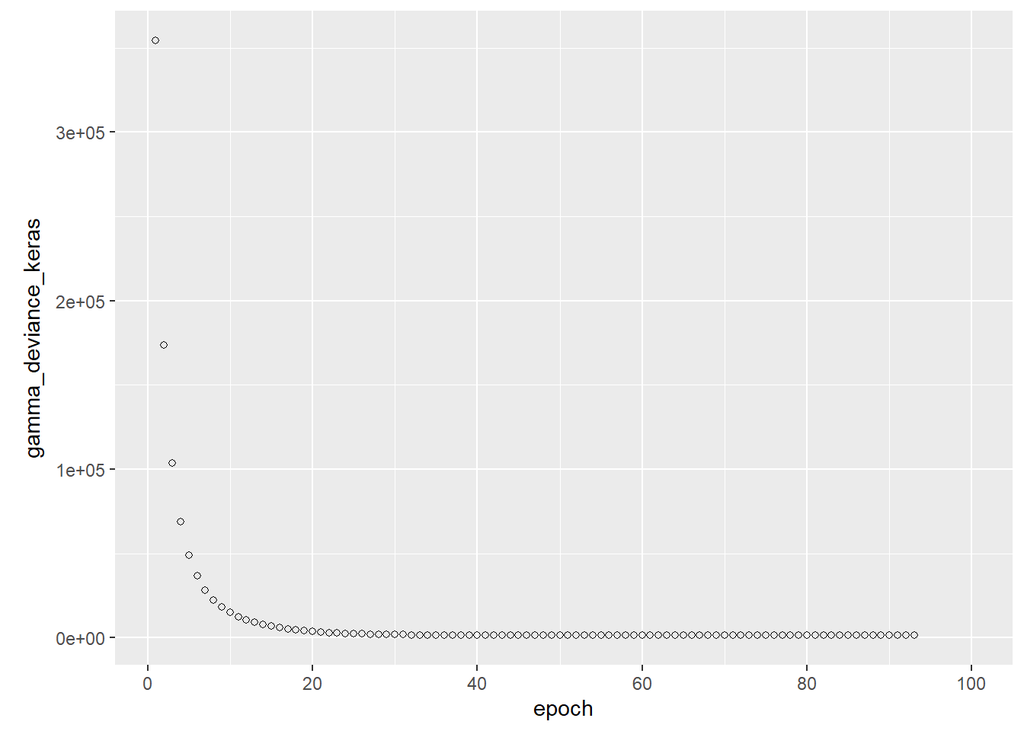

```r
plot(model1$layers$size$history, metrics = 'gamma_deviance_keras', smooth = FALSE)
```

Let’s compare with the homogeneous GLM (gamma log link):

```r
glm.hom <- hirem(reserving_data) %>%
  split_data(observed = reserving_data %>% dplyr::filter(calendar_year <= 6),
             validation = .7, cv_fold = 6) %>%
  layer_glm('size', Gamma(link = log),
            filter = function(data){data$payment == 1})

glm.hom <- hirem::fit(glm.hom,
                      size = 'size ~ 1')
```

```
## Fitting layer_glm ...
```

The obtained coefficients are (almost) identical:

```r
print(glm.hom$layers$size$fit$coefficients)
```

```
## (Intercept)
##    6.254096
```

```r
print(model1$layers$size$fit$weights)
```

```
## [[1]]
## <tf.Variable 'output_layer/kernel:0' shape=(1, 1) dtype=float32, numpy=array([[6.2547603]], dtype=float32)>
```

The shape parameter of the gamma distribution are (almost) identical:

```r
print(glm.hom$layers$size$shape)
```

```
## [1] 0.8377174
```

```r
print(model1$layers$size$shape)
```

```
## [1] 0.8377171
```

# Shallow MLP with weight initialization

The only difference with the previous case is that we initialize the bias weight of the output layer with the coefficient estimate of the homogeneous GLM (parameter ‘family_for_init’). This allows for a faster convergence of the gradient descent algorithm. For more information, see Ferrario, Andrea and Noll, Alexander and Wuthrich, Mario V., Insights from Inside Neural Networks (April 23, 2020). Available at SSRN: https://ssrn.com/abstract=3226852 or http://dx.doi.org/10.2139/ssrn.3226852 p.29.

```r
model2 <- hirem(reserving_data) %>%
  split_data(observed = reserving_data %>% dplyr::filter(calendar_year <= 6),
             validation = .7, cv_fold = 6) %>%
  layer_glm('close', binomial(link = logit)) %>%
  layer_glm('payment', binomial(link = logit)) %>%
  layer_mlp_keras('size', distribution = 'gamma',
                  step_log = F,
                  step_normalize = F,
                  loss = gamma_deviance_keras,
                  metrics = metric_gamma_deviance_keras,
                  optimizer = optimizer_nadam(learning_rate = .01),
                  validation_split = 0,
                  hidden = NULL,
                  activation.output = 'exponential',
                  batch_normalization = F,
                  family_for_init = Gamma(link = log),
                  epochs = 100,
                  batch_size = 1000,
                  monitor = 'gamma_deviance_keras',
                  patience = 20,
                  filter = function(data){data$payment == 1})

model2 <- hirem::fit(model2,
                      close = 'close ~ factor(development_year)',
                      payment = 'payment ~ close + factor(development_year)',
                      size = 'size ~ close + development_year_factor')
```

```
## Fitting layer_glm ...
## Fitting layer_glm ...
## Fitting layer_mlp_keras ...
## Model: "model_1"
## ________________________________________________________________________________
## Layer (type)                        Output Shape                    Param #
## ================================================================================
## input_2 (InputLayer)                [(None, 6)]                     0
## ________________________________________________________________________________
## output_layer (Dense)                (None, 1)                       7
## ================================================================================
## Total params: 7
## Trainable params: 7
## Non-trainable params: 0
## ________________________________________________________________________________
## NULL
```

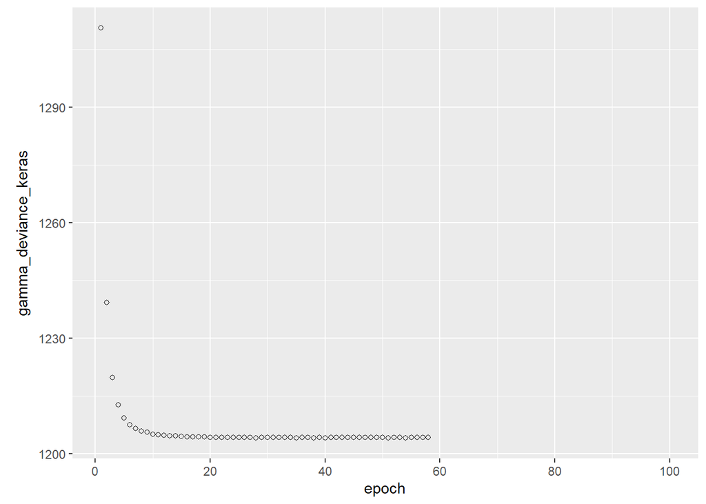

```r
plot(model2$layers$size$history, metrics = 'gamma_deviance_keras', smooth = FALSE)
```

The shape parameter is (almost) identical to model 1 (glm, gamma log link for size):

```r
print(model2$layers$size$shape)
```

```
## [1] 0.9565545
```

```r
print(model2$layers$size$shape.se)
```

```
## [1] 0.003784558
```

```r
print(model1$layers$size$shape)
```

```
## [1] 0.8377171
```

```r
print(model1$layers$size$shape.se)
```

```
## [1] 0.003274592
```

We then compute the simulated RBNS reserves and compare them with the true value.

```r
simulate_rbns(model2)
```

```
## # A tibble: 5 x 2
##   simulation rbns_simulated
##        <int>          <dbl>
## 1          1       8988259.
## 2          2       8161865.
## 3          3       9615840.
## 4          4       9053265.
## 5          5       9518876.
##   rbns_actual
## 1     8538356
```